# deeper EDA

# Analysis of Adverse Food Event 食物不良反應事件分析

## 1.整理資料

```r
library(readr)
library(lattice)
library(tidyverse)
library(stringr)
library(lubridate)
library(DT)
rm(list=ls())

AdverseFoodEvents = read_csv("adversefoodevent_data.csv")

AdverseFoodEvents = AdverseFoodEvents %>%
  rename(ReportNo = `RA_Report #`) %>%
  rename(IndustryName = `PRI_FDA Industry Name`) %>%
  rename(AgeUnit = `CI_Age Unit`) %>%
  rename(AgeAtAdverseEvent = `CI_Age at Adverse Event`) %>%
  rename(Gender = `CI_Gender`) %>%
  rename(Outcomes = `AEC_One Row Outcomes`) %>%
  rename(Symptoms = `SYM_One Row Coded Symptoms`)

TransformIntoYears = function(ds)
  {if(!is.na(ds["AgeAtAdverseEvent"]))
  { x = as.numeric(ds["AgeAtAdverseEvent"])
  ds["AgeAtAdverseEvent"] = as.numeric(ds["AgeAtAdverseEvent"])
  if(ds["AgeUnit"] == "Month(s)")
  {ds["AgeAtAdverseEventInYears"] = x/12}
  else if (ds["AgeUnit"] == "Weeks(s)")
  {ds["AgeAtAdverseEventInYears"] = x*7/365}
  else if (ds["AgeUnit"] == "Day(s)")
  {ds["AgeAtAdverseEventInYears"] = x*1/365}
  else if (ds["AgeUnit"] == "Decade(s)")
  {ds["AgeAtAdverseEventInYears"] = x*10}  }
    return(ds)}

  AdverseFoodEvents = AdverseFoodEvents %>%
    mutate(AgeAtAdverseEventInYears = AgeAtAdverseEvent)

  AdverseFoodEvents$AgeAtAdverseEventInYears =
    as.numeric(AdverseFoodEvents$AgeAtAdverseEventInYears)

  AdverseFoodEvents = sapply(AdverseFoodEvents,TransformIntoYears)

  AdverseFoodEvents = as.data.frame(AdverseFoodEvents)

colnames(AdverseFoodEvents)
```

```
##  [1] "ReportNo"                        "RA_CAERS Created Date"
##  [3] "AEC_Event Start Date"            "PRI_Product Role"
##  [5] "PRI_Reported Brand/Product Name" "PRI_FDA Industry Code"
##  [7] "IndustryName"                    "AgeAtAdverseEvent"
##  [9] "AgeUnit"                         "Gender"
## [11] "Outcomes"                        "Symptoms"
## [13] "AgeAtAdverseEventInYears"
```

## 2.看資料結構和基本統計

```r
summary(afe2)
```

```
##     ReportNo     RA_CAERS.Created.Date AEC_Event.Start.Date
##  179852 :   44   8/3/2016 :  159       8/1/2016:   68
##  117851 :   39   8/4/2016 :  136       8/1/2014:   64
##  190041 :   35   4/18/2017:  130       1/1/2015:   63
##  153719 :   31   7/29/2016:  123       1/1/2014:   62
##  192894 :   27   8/5/2016 :  123       7/1/2016:   62
##  194925 :   25   1/31/2017:  104       6/1/2016:   61
##  (Other):35227   (Other)  :34653       (Other) :35048
##     PRI_Product.Role PRI_Reported.Brand.Product.Name PRI_FDA.Industry.Code
##  Concomitant: 8784   REDACTED    :  610              54     :22389
##  Suspect    :26644   VITAMIN D   :  420              53     : 3571
##                      MULTIVITAMIN:  404              16     :  960
##                      FISH OIL    :  326              23     :  853
##                      CALCIUM     :  317              41     :  733
##                      VITAMIN C   :  277              40     :  719
##                      (Other)     :33074              (Other): 6203
##                                  IndustryName   AgeAtAdverseEvent
##  Vit/Min/Prot/Unconv Diet(Human/Animal):22389   50     :  665
##  Cosmetics                             : 3571   55     :  651
##  Fishery/Seafood Prod                  :  960   52     :  647
##  Vegetables/Vegetable Products         :  950   58     :  625
##  Nuts/Edible Seed                      :  853   42     :  613
##  Dietary Conv Food/Meal Replacements   :  733   57     :  612
##  (Other)                               : 5972   (Other):31615
##           AgeUnit                Gender
##  Day(s)       :  128   Female       :23061
##  Decade(s)    :    1   Male         :11551
##  Month(s)     :  928   Not Available:  814
##  Not Available:    9   Not Reported :    1
##  Week(s)      :  135   Unknown      :    1
##  Year(s)      :34227
##
##                                                                      Outcomes
##  OTHER SERIOUS (IMPORTANT MEDICAL EVENTS)                                : 7414
##  NON-SERIOUS INJURIES/ ILLNESS                                           : 6459
##  HOSPITALIZATION                                                         : 2900
##  VISITED A HEALTH CARE PROVIDER, OTHER SERIOUS (IMPORTANT MEDICAL EVENTS): 2357
##  HOSPITALIZATION, VISITED AN ER                                          : 1382
##  OTHER SERIOUS (IMPORTANT MEDICAL EVENTS), VISITED AN ER                 : 1372
##  (Other)                                                                 :13544
##                Symptoms     AgeAtAdverseEventInYears
##  ALOPECIA          :  523   50     :  665
##  CHOKING           :  368   55     :  651
##  VOMITING          :  314   52     :  647
##  DIARRHOEA         :  304   58     :  625
##  ALOPECIA, ALOPECIA:  269   42     :  613
##  OVARIAN CANCER    :  214   57     :  612
##  (Other)           :33436   (Other):31615
```

```r
head(afe2)
```

```
##    ReportNo RA_CAERS.Created.Date AEC_Event.Start.Date PRI_Product.Role
## 1     65325              1/1/2004             8/4/2003          Suspect
## 2     65325              1/1/2004             8/4/2003          Suspect
## 4     65335              1/1/2004           11/24/2003          Suspect
## 6     65345              1/1/2004           12/21/2003          Suspect
## 17    65399              1/5/2004           11/22/2003          Suspect
## 18    65400              1/5/2004             9/5/2001          Suspect
##                  PRI_Reported.Brand.Product.Name PRI_FDA.Industry.Code
## 1  MIDWEST COUNTRY FAIR CHOCOLATE FLAVORED CHIPS                     3
## 2  MIDWEST COUNTRY FAIR CHOCOLATE FLAVORED CHIPS                     3
## 4                     ENFAMIL LIPIL BABY FORMULA                    40
## 6    FRITO LAY FUNYUNS ONION FLAVOR, ONION RINGS                     7
## 17                                METOBOLITE 356                    54
## 18                                    METABOLIFE                    54
##                              IndustryName AgeAtAdverseEvent  AgeUnit
```

[output cut: 34 more lines]

```r
str(afe2)
```

```
## 'data.frame':    35428 obs. of  13 variables:
##  $ ReportNo                       : Factor w/ 64517 levels "100008","100011",..: 55052 55052 55054 55056 55066 55067 55068 55070 55072 55072 ...
##  $ RA_CAERS.Created.Date          : Factor w/ 4020 levels "1/1/2004","1/1/2008",..: 1 1 1 1 286 286 286 298 298 298 ...
##  $ AEC_Event.Start.Date           : Factor w/ 5174 levels "1/1/1950","1/1/1983",..: 4675 4675 1122 1500 1094 5103 2523 979 897 897 ...
##  $ PRI_Product.Role               : Factor w/ 2 levels "Concomitant",..: 2 2 2 2 2 2 2 2 2 2 ...
##  $ PRI_Reported.Brand.Product.Name: Factor w/ 45662 levels "\"A LOT OF HEALTH PRODUCTS\"",..: 24003 24003 11629 13927 23931 23795 23803 2296 8380 10051 ...
##  $ PRI_FDA.Industry.Code          : Factor w/ 44 levels "12","13","14",..: 19 19 31 43 42 42 42 42 21 18 ...
##  $ IndustryName                   : Factor w/ 41 levels "Alcoholic Beverage",..: 3 3 2 33 40 40 40 40 9 34 ...
##  $ AgeAtAdverseEvent              : Factor w/ 115 levels "0","1","10","100",..: 26 26 38 3 62 55 65 45 42 42 ...
##  $ AgeUnit                        : Factor w/ 6 levels "Day(s)","Decade(s)",..: 6 6 3 6 6 6 6 6 6 6 ...
##  $ Gender                         : Factor w/ 5 levels "Female","Male",..: 1 1 3 2 2 1 1 1 2 2 ...
##  $ Outcomes                       : Factor w/ 298 levels "CONGENITAL ANOMALY",..: 292 292 177 177 22 22 164 226 163 163 ...
##  $ Symptoms                       : Factor w/ 33546 levels "ABASIA","ABASIA, ABASIA",..: 29216 29238 15796 6440 7489 8336 5804 17650 25749 25749 ...
##  $ AgeAtAdverseEventInYears       : Factor w/ 115 levels "0","1","10","100",..: 26 26 38 3 62 55 65 45 42 42 ...
##  - attr(*, "na.action")= 'omit' Named int  3 5 7 8 9 10 11 12 13 14 ...
##   ..- attr(*, "names")= chr  "3" "5" "7" "8" ...
```

## 3. 查看性別和年齡間的關係

- 利用filter()篩選出性別和年齡資料，排除未知的資料
- 透過ggplot2作圖，作箱型圖

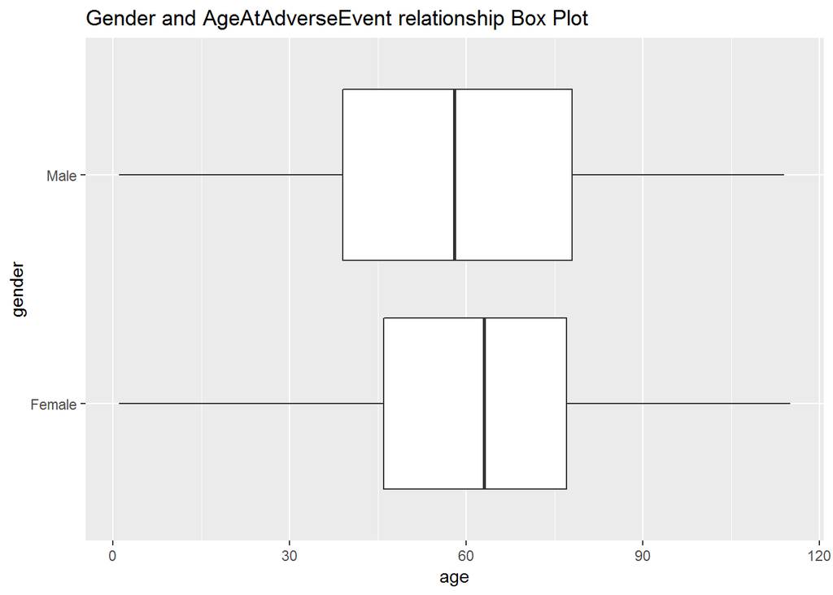

```r
afe <- data.frame(AdverseFoodEvents)

afeg <- filter(afe2, Gender %in% c("Male","Female")) %>%
  mutate(AgeAtAdverseEventInYears= as.numeric(AgeAtAdverseEventInYears))
library(ggplot2)
  ggplot(data = afeg, aes(x = Gender, y = AgeAtAdverseEventInYears)) +
    geom_boxplot() + coord_flip() +
    labs( y = 'age', x = 'gender',
          title = 'Gender and AgeAtAdverseEvent relationship Box Plot')
```

### 從box plot看出，發生不良反應事件中，女性平均年齡高於男性

## 4. 計算95%信賴區間

```r
with(afeg,
     tapply(AgeAtAdverseEventInYears, Gender,
     function(x)
       c(mean(x) + c(-2, 2) * sd(x)/sqrt(length(x)))))
```

```
## $Female
## [1] 61.33547 61.90099
##
## $Male
## [1] 57.48366 58.39670
##
## $`Not Available`
## NULL
##
## $`Not Reported`
## NULL
##
## $Unknown
## NULL
```

### 故在95%信賴區間下，

### 女性年齡範圍落在61.3至61.9歲，男性則落在57.4至58.3歲

## 5. 用 t-test 檢驗在食物不良反應發生的事件中，性別和年齡間是否存在差異

- H0: 女性所屬母群平均年齡 = 男性所屬母群平均年齡
- H1: 女性所屬母群平均年齡和男性所屬母群平均年齡不相等

```r
t.test(AgeAtAdverseEventInYears ~ Gender, data = afeg)
```

```
##
##  Welch Two Sample t-test
##
## data:  AgeAtAdverseEventInYears by Gender
## t = 13.699, df = 20594, p-value < 2.2e-16
## alternative hypothesis: true difference in means is not equal to 0
## 95 percent confidence interval:
##  3.151774 4.204330
## sample estimates:
## mean in group Female   mean in group Male
##             61.61823             57.94018
```

- 加上參數 var.equal=TRUE 來假設變異數相同，不做Welch校正

```r
t.test(AgeAtAdverseEventInYears ~ Gender, data = afeg, var.equal = TRUE)
```

```
##
##  Two Sample t-test
##
## data:  AgeAtAdverseEventInYears by Gender
## t = 14.316, df = 34610, p-value < 2.2e-16
## alternative hypothesis: true difference in means is not equal to 0
## 95 percent confidence interval:
##  3.174494 4.181609
## sample estimates:
## mean in group Female   mean in group Male
##             61.61823             57.94018
```

### (1)在發生食物不良反應的事件中，女性所屬母群平均年齡為61.6歲(約62歲)，男性所屬母群平均年齡57.9歲(約58歲)

### (2)由於alternative hypothesis: true difference in means is not equal to 0，代表男女性別的平均年齡差不等於0，即男性和女性平均發生食物不良反應的年齡有顯著差異。

## 6. 查看年齡和所吃的食物產品間是否有關

* 前5項最多食物不良反應的產品數量圖

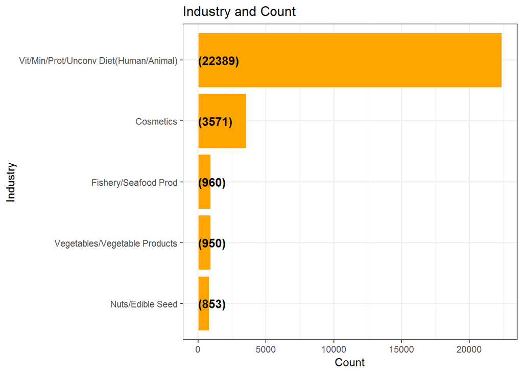

```r
afe2 %>%
  group_by(IndustryName) %>%
  summarise(Count = n()) %>%
  arrange(desc(Count)) %>%
  ungroup() %>%
  mutate(IndustryName = reorder(IndustryName,Count)) %>%
  head(5) %>%
ggplot(aes(x = IndustryName,y = Count)) +
  geom_bar(stat='identity',colour="white", fill = "orange") +
  geom_text(aes(x = IndustryName, y = 1, label = paste0("(",Count,")",sep="")),
            hjust=0, vjust=.5, size = 4, colour = 'black',
            fontface = 'bold') +
  labs(x = 'Industry',
       y = 'Count',
       title = 'Industry and Count') +
  coord_flip() +
  theme_bw()
```

### 前五項分別為:(1)營養補充品(2)化妝品(3)魚類/海鮮(4)蔬菜(5)堅果種子

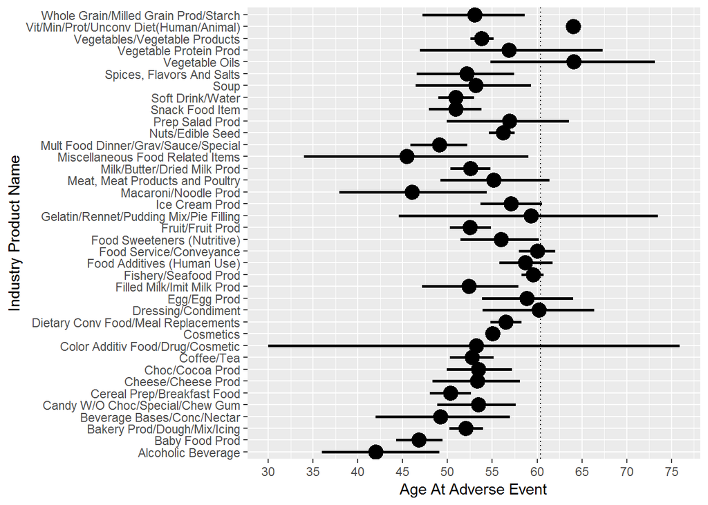

```r
library(ggplot2)
ggplot(data = afeg,
        aes(x = IndustryName, y = AgeAtAdverseEventInYears)) +
   stat_summary(fun.data = 'mean_cl_boot', size = 1) +
   scale_y_continuous(breaks = seq(0, 100, by = 5)) +
   geom_hline(yintercept = mean(afeg$AgeAtAdverseEventInYears) ,
              linetype = 'dotted') +
   labs(x = 'Industry Product Name', y = 'Age At Adverse Event') +
   coord_flip()
```

## ANOVA分析

- 1. df 自由度 2.sum sq 平方和 3.Mean sq 均方 4. F value F值

```r
anova(m1 <- lm(AgeAtAdverseEventInYears ~ IndustryName, data = afeg))
```

```
## Analysis of Variance Table
##
## Response: AgeAtAdverseEventInYears
##                 Df   Sum Sq Mean Sq F value    Pr(>F)
## IndustryName    37   927213 25059.8  51.702 < 2.2e-16 ***
## Residuals    34574 16757927   484.7
## ---
## Signif. codes:  0 '***' 0.001 '**' 0.01 '*' 0.05 '.' 0.1 ' ' 1
```

### 其結果呈現p< 2.2e-16，代表p值遠小於0.05，即在造成食物不良反應的各產品所屬母群平均數有顯著差異。

- 推測使用導致食物不良之常見產品可能和性別年齡不同有關，並畫圖觀察

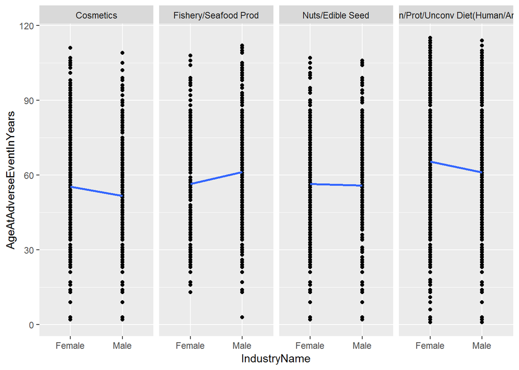

```r
afei <- filter(afeg, IndustryName %in% c("Vit/Min/Prot/Unconv Diet(Human/Animal)","Fishery/Seafood Prod","Cosmetics","Vegetables/Vegetable Products
","Nuts/Edible Seed"))
ggplot(data = afei,
       aes(group = IndustryName,
          y = AgeAtAdverseEventInYears, x = Gender)) +
  geom_point() +
  stat_smooth(method = 'lm', se = F) +
  stat_smooth(aes(group = IndustryName,
          y = AgeAtAdverseEventInYears, x =  Gender),
          method = 'lm', se = F) +
  facet_grid( . ~  IndustryName) +
  labs(x = 'IndustryName', y = 'AgeAtAdverseEventInYears')
```

## 7. 利用以下 ANOVA 檢驗假設是否正確

- 利用以下 ANOVA 檢驗假設是否正確 把性別加進模型

```r
anova(m2 <- update(m1, . ~ . +
            Gender, data = afeg))
```

```
## Analysis of Variance Table
##
## Response: AgeAtAdverseEventInYears
##                 Df   Sum Sq Mean Sq F value    Pr(>F)
## IndustryName    37   927213   25060  51.996 < 2.2e-16 ***
## Gender           1    95161   95161 197.446 < 2.2e-16 ***
## Residuals    34573 16662765     482
## ---
## Signif. codes:  0 '***' 0.001 '**' 0.01 '*' 0.05 '.' 0.1 ' ' 1
```

### 其結果呈現p<2.2e-16，代表p值遠小於0.05，即在造成食物不良反應的各產品所屬母群平均數和性別所屬母群平均數有顯著差異。

或許不是產品種類，而是和性別有關

```r
anova(m3 <- update(m2, . ~ . - IndustryName,  data = afeg))
```

```
## Analysis of Variance Table
##
## Response: AgeAtAdverseEventInYears
##              Df   Sum Sq Mean Sq F value    Pr(>F)
## Gender        1   104113  104113  204.96 < 2.2e-16 ***
## Residuals 34610 17581027     508
## ---
## Signif. codes:  0 '***' 0.001 '**' 0.01 '*' 0.05 '.' 0.1 ' ' 1
```

### 其結果呈現p<2.2e-16，代表p值遠小於0.05，即發生食物不良反應性別所屬母群平均數有顯著差異。

## 8.將 ANOVA 結果做成圖表輸出，先計算所需要的數據

- 比較在控制性別下，產品種類的效果

```r
res_lm <- lapply(list(m1, m2, m3), summary)
(res_lm[[2]]$r.sq - res_lm[[3]]$r.sq)/res_lm[[2]]$r.sq
```

```
## [1] 0.8981651
```

```r
anova(m3, m2)
```

```
## Analysis of Variance Table
##
## Model 1: AgeAtAdverseEventInYears ~ Gender
## Model 2: AgeAtAdverseEventInYears ~ IndustryName + Gender
##   Res.Df      RSS Df Sum of Sq      F    Pr(>F)
## 1  34610 17581027
## 2  34573 16662765 37    918261 51.494 < 2.2e-16 ***
## ---
## Signif. codes:  0 '***' 0.001 '**' 0.01 '*' 0.05 '.' 0.1 ' ' 1
```

- 比較在控制產品種類下，性別的效果

```r
(res_lm[[2]]$r.sq - res_lm[[1]]$r.sq)/res_lm[[1]]$r.sq
```

```
## [1] 0.1026313
```

```r
anova(m1, m2)
```

```
## Analysis of Variance Table
##
## Model 1: AgeAtAdverseEventInYears ~ IndustryName
## Model 2: AgeAtAdverseEventInYears ~ IndustryName + Gender
##   Res.Df      RSS Df Sum of Sq      F    Pr(>F)
## 1  34574 16757927
## 2  34573 16662765  1     95161 197.45 < 2.2e-16 ***
## ---
## Signif. codes:  0 '***' 0.001 '**' 0.01 '*' 0.05 '.' 0.1 ' ' 1
```

## 9. 作圖

```r
library(coefplot)
(m1 <- lm(AgeAtAdverseEventInYears ~ IndustryName, data = afe2))
```

```
##
## Call:
## lm(formula = AgeAtAdverseEventInYears ~ IndustryName, data = afe2)
##
## Coefficients:
##                                        (Intercept)
##                                             38.000
##                         IndustryNameBaby Food Prod
##                                              6.338
##            IndustryNameBakery Prod/Dough/Mix/Icing
##                                             10.317
##             IndustryNameBeverage Bases/Conc/Nectar
##                                              9.093
##        IndustryNameCandy W/O Choc/Special/Chew Gum
##                                             11.754
##             IndustryNameCereal Prep/Breakfast Food
##                                              8.987
##                     IndustryNameCheese/Cheese Prod
##                                             11.263
##                        IndustryNameChoc/Cocoa Prod
##                                             11.989
##                             IndustryNameCoffee/Tea
##                                             10.788
##       IndustryNameColor Additiv Food/Drug/Cosmetic
##                                             12.222
##                              IndustryNameCosmetics
##                                             13.047
##    IndustryNameDietary Conv Food/Meal Replacements
##                                             14.494
##                     IndustryNameDressing/Condiment
##                                             15.867
##                           IndustryNameEgg/Egg Prod
##                                             16.091
##             IndustryNameFilled Milk/Imit Milk Prod
##                                             10.915
##                   IndustryNameFishery/Seafood Prod
##                                             17.541
##             IndustryNameFood Additives (Human Use)
##                                             16.409
##                IndustryNameFood Service/Conveyance
```

[output cut: 26 more lines]

```
##                                              8.813
##                                   IndustryNameSoup
##                                             11.000
##              IndustryNameSpices, Flavors And Salts
##                                             10.172
##                         IndustryNameVegetable Oils
##                                             21.600
##                 IndustryNameVegetable Protein Prod
##                                             14.870
##          IndustryNameVegetables/Vegetable Products
##                                             12.031
## IndustryNameVit/Min/Prot/Unconv Diet(Human/Animal)
##                                             22.075
##   IndustryNameWhole Grain/Milled Grain Prod/Starch
##                                             11.013
```

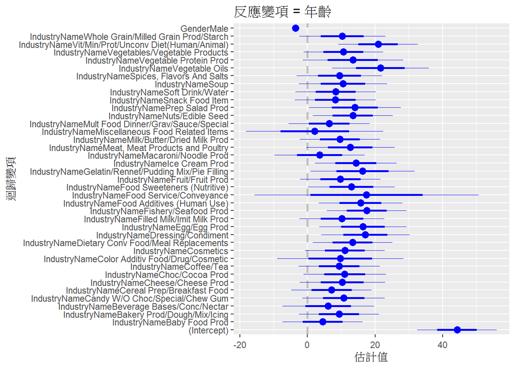

```r
coefplot(m2, xlab = '估計值', ylab = '迴歸變項', title = '反應變項 = 年齡')
```

## 10. 把資料與迴歸分析的預測值、殘差與影響度放進資料

```r
fit_m2 <- data.frame(afeg[, c(7, 10, 13)], fitted = fitted(m2), resid = resid(m2),
                     infl = influence(m2)$hat )
```

## 12. 看殘差分配，依食物產品，檢視常態與變異數同質假設

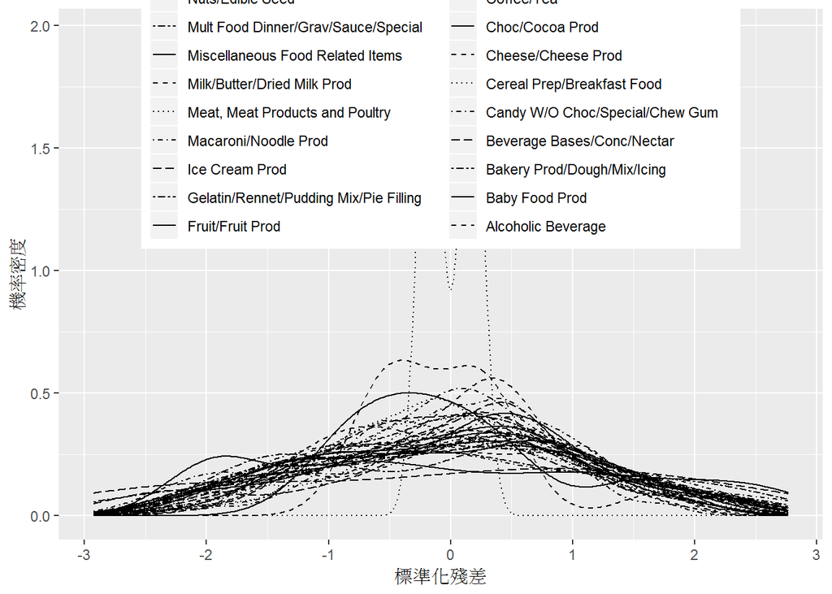

```r
ggplot(data = fit_m2, aes(x = scale(resid)), group = IndustryName ) +
 stat_density(geom = 'path', position = 'identity', aes(linetype = IndustryName)) +
 scale_linetype_manual(values = 38:1) +
 guides(linetype = guide_legend(reverse = TRUE)) +
 labs(x = '標準化殘差', y = '機率密度') +
 theme(legend.position = c(.5, 1.1) )
```

## 13 看看殘差的 Q-Q 圖，依食物產品。檢視常態假設

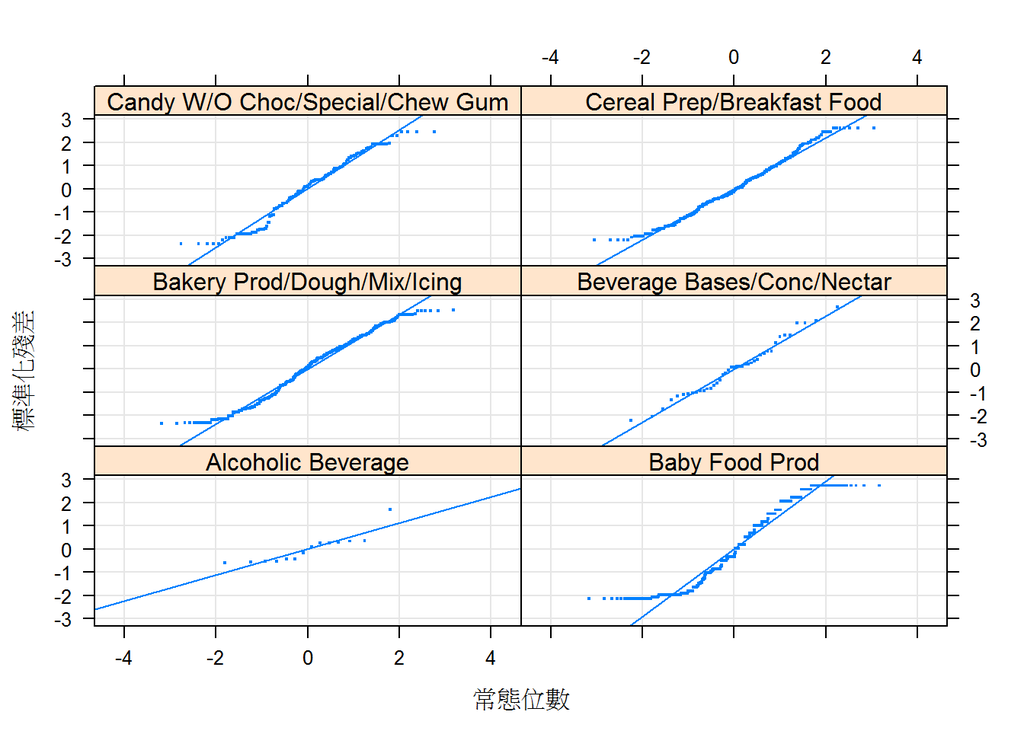

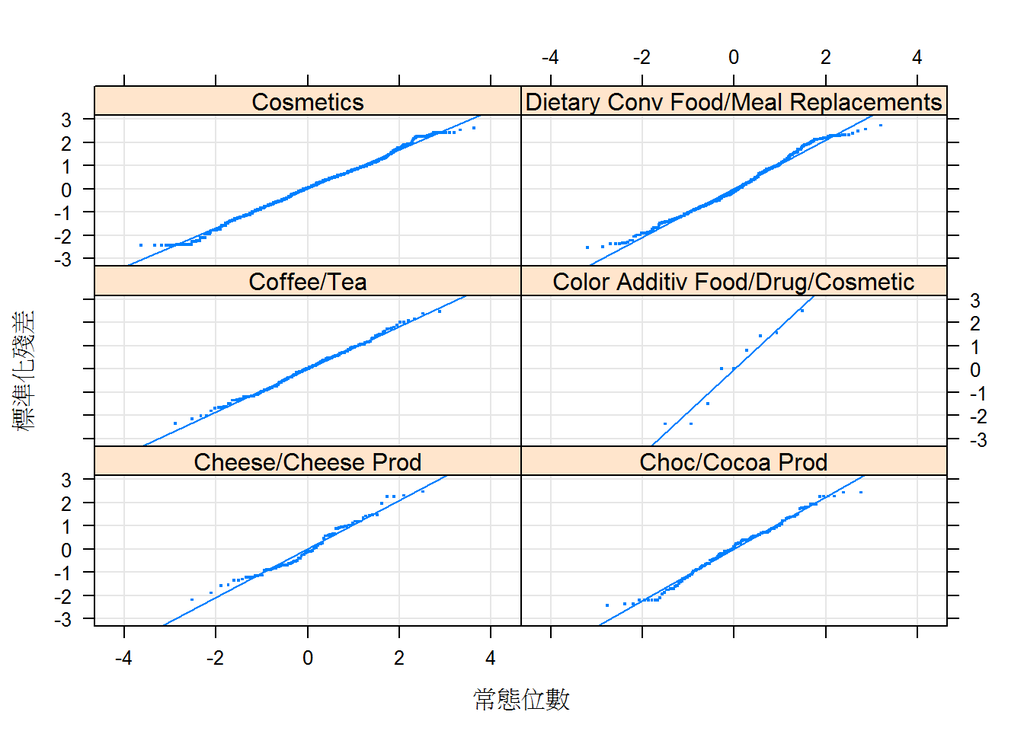

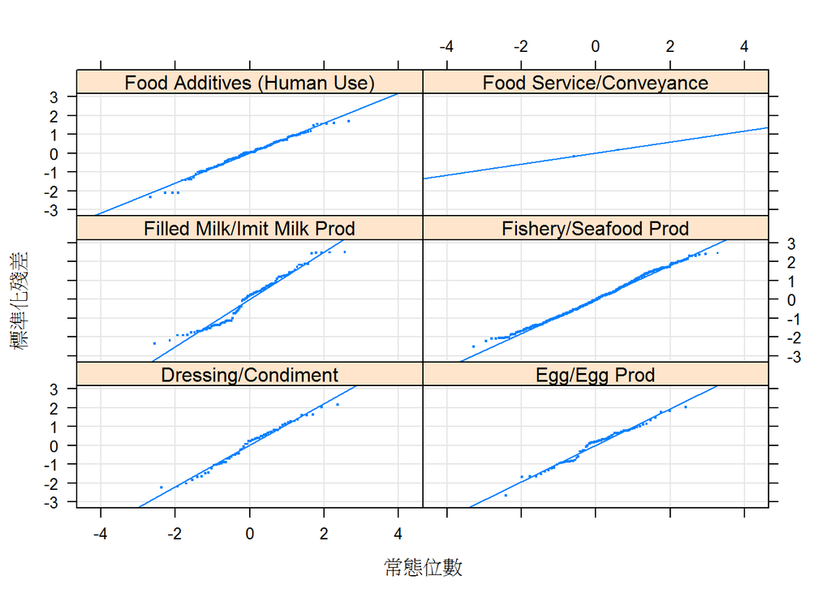

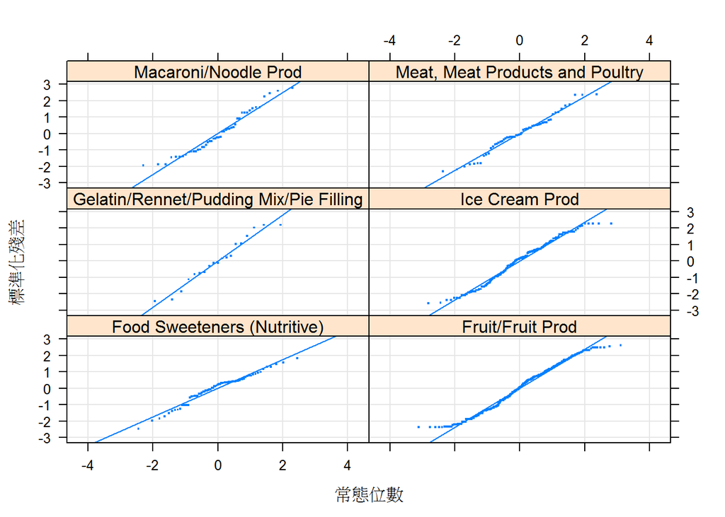

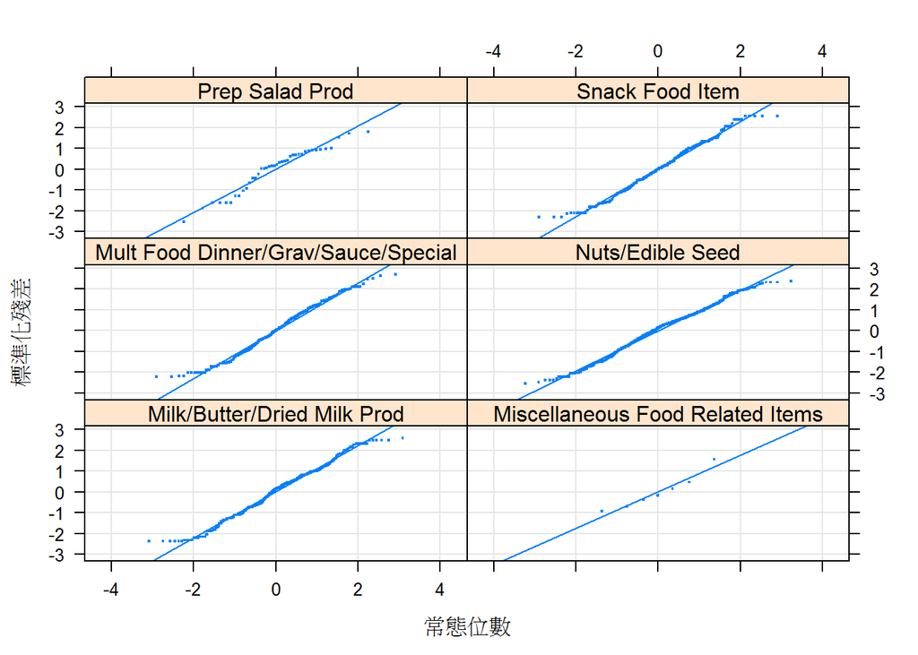

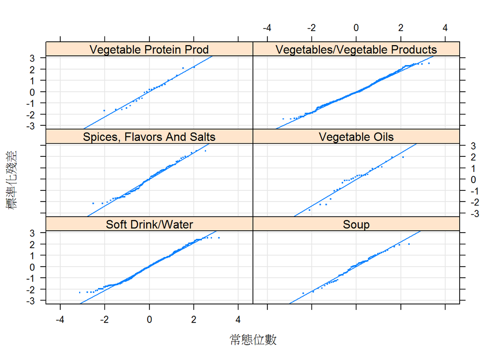

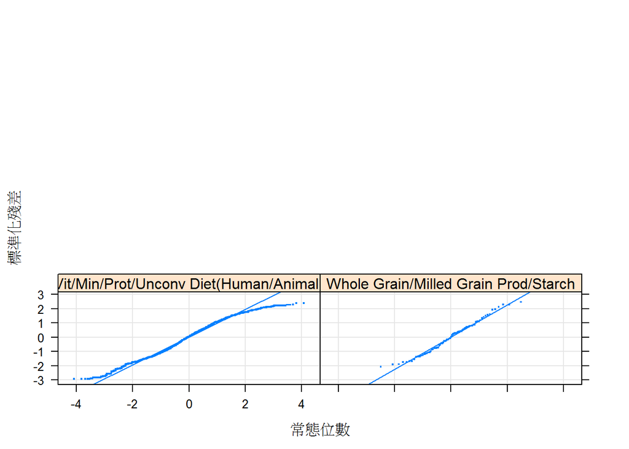

```r
require(lattice)
qqmath(~ scale(resid) | IndustryName, data = fit_m2, type = c('p', 'g', 'r'),
       xlab = '常態位數', ylab = '標準化殘差', layout = c(2, 3),
       pch = '.', cex = 2)
```

## 14 畫預測值與殘差的散佈圖，檢查線性與等分散假設

```r
require(MASS)
```

[figure not shown]

```r
ggplot(data = fit_m2, aes(x = fitted, y = scale(resid), group = IndustryName )) +
  geom_point(pch = 20, size = 1) +
  stat_smooth(method = 'rlm', se = F) +
  facet_grid(IndustryName ~ .) +
  labs(x = '年齡預測值', y = '標準化殘差')
```

## 15 呈現影響值（影響估計結果過大的值）與標準化殘差

[figure not shown]

```r
ggplot(data = fit_m2, aes(x = infl, y = scale(resid), group = IndustryName)) +
 geom_text(aes(label = rownames(fit_m2)), cex = 2) +
 geom_hline(yintercept = 0, linetype = 'dotted') +
 facet_grid(IndustryName ~ .) +
 labs(x = '影響值', y = '標準化殘差')
```

## 16 看看影響值

```r
summary(influence(m2)$hat)
```

```
##      Min.   1st Qu.    Median      Mean   3rd Qu.      Max.
## 0.0000602 0.0000602 0.0001071 0.0011268 0.0010685 0.5000341
```

## 17 分析資料集當中的其他變項是否和年齡有關

- 原先為factor型，要先轉成numeric，而sapply(data,class)可看資料類型

```r
afeg$ReportNo <- as.numeric(as.character(afeg$ReportNo))
afeg$PRI_FDA.Industry.Code <- as.numeric(as.character(afeg$PRI_FDA.Industry.Code))
sapply(afeg, class)
```

```
##                        ReportNo           RA_CAERS.Created.Date
##                       "numeric"                        "factor"
##            AEC_Event.Start.Date                PRI_Product.Role
##                        "factor"                        "factor"
## PRI_Reported.Brand.Product.Name           PRI_FDA.Industry.Code
##                        "factor"                       "numeric"
##                    IndustryName               AgeAtAdverseEvent
##                        "factor"                        "factor"
##                         AgeUnit                          Gender
##                        "factor"                        "factor"
##                        Outcomes                        Symptoms
##                        "factor"                        "factor"
##        AgeAtAdverseEventInYears
##                       "numeric"
```

```r
dta_age <- afeg[, c("AgeAtAdverseEventInYears","PRI_FDA.Industry.Code","ReportNo")]
```

## 18 觀看基本統計量

```r
colMeans(dta_age)
```

```
## AgeAtAdverseEventInYears    PRI_FDA.Industry.Code                 ReportNo
##                 60.39076                 45.66910             159998.76525
```

## 19 呈現兩兩散佈圖

- 需用heplots套件

```r
library(heplots)
```

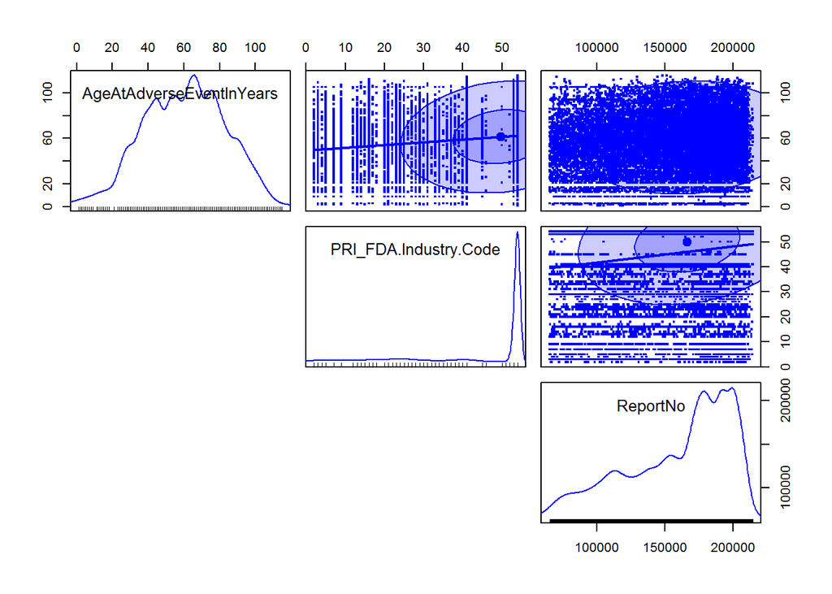

```r
scatterplotMatrix(~ AgeAtAdverseEventInYears + PRI_FDA.Industry.Code + ReportNo, data= dta_age,
  pch = '.', cex = 3, smooth = FALSE, reg.line = FALSE, ellipse = TRUE,
  diagonal = 'none', lower.panel = NULL)
```

## 20 利用corrplot 套件，以圖形顯示相關性的大小

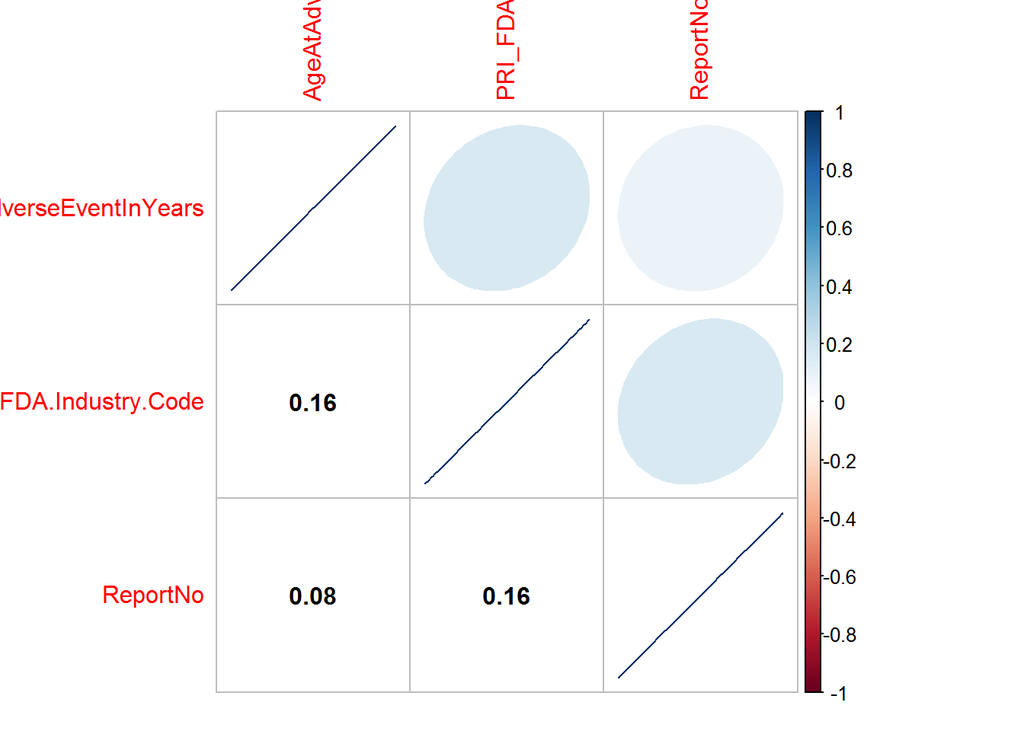

```r
library(corrplot)
corrplot(cor(dta_age), method = 'ellipse', order = 'hclust', addrect = 4,
         type = 'upper', tl.pos = 'tp')
corrplot(cor(dta_age), add = TRUE, type = 'lower', method = 'number',
         order = 'hclust', col = 'black', diag = FALSE, tl.pos = 'n', cl.pos = 'n')
```

## 21 加入解釋變項

```r
summary(m4 <- lm(AgeAtAdverseEventInYears ~ PRI_FDA.Industry.Code + ReportNo, data = dta_age))
```

```
##
## Call:
## lm(formula = AgeAtAdverseEventInYears ~ PRI_FDA.Industry.Code +
##     ReportNo, data = dta_age)
##
## Residuals:
##     Min      1Q  Median      3Q     Max
## -62.448 -16.830   0.766  16.093  59.373
##
## Coefficients:
##                        Estimate Std. Error t value Pr(>|t|)
## (Intercept)           4.446e+01  5.889e-01   75.49   <2e-16 ***
## PRI_FDA.Industry.Code 2.292e-01  8.031e-03   28.54   <2e-16 ***
## ReportNo              3.414e-05  3.181e-06   10.73   <2e-16 ***
## ---
## Signif. codes:  0 '***' 0.001 '**' 0.01 '*' 0.05 '.' 0.1 ' ' 1
##
## Residual standard error: 22.27 on 34609 degrees of freedom
## Multiple R-squared:  0.02967,    Adjusted R-squared:  0.02961
## F-statistic: 529.1 on 2 and 34609 DF,  p-value: < 2.2e-16
```

> 在Pr(>|t|)欄，可以瞭解到回歸係數顯著不為0（p<2e-16），而R平方項為0.02961，表明模型只能解釋應變量2.9%的方差；殘差的標準誤為22.27 ，則可視為回歸模型用來做預測的平均誤差。

## 結果呈現

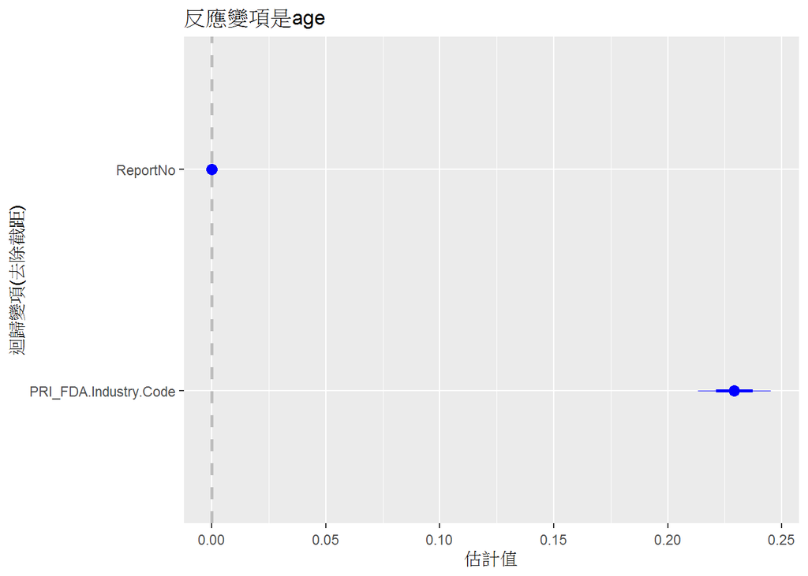

```r
coefplot(m4, predictors = c("ReportNo","PRI_FDA.Industry.Code","AgeAtAdverseEventInYears"),
 xlab = '估計值', ylab = '迴歸變項(去除截距)', title = '反應變項是age')
```

## 22 使用effects套件

```r
library(effects)
```

[figure not shown]

```r
plot(allEffects(m4), main = '', ylim = c(550, 670), grid = T)
```

## 23 利用 lm.beta 套件，計算標準化迴歸係數

```r
library(lm.beta)
summary(lm.beta(m4))
```

```
##
## Call:
## lm(formula = AgeAtAdverseEventInYears ~ PRI_FDA.Industry.Code +
##     ReportNo, data = dta_age)
##
## Residuals:
##     Min      1Q  Median      3Q     Max
## -62.448 -16.830   0.766  16.093  59.373
##
## Coefficients:
##                        Estimate Standardized Std. Error t value Pr(>|t|)
## (Intercept)           4.446e+01    0.000e+00  5.889e-01   75.49   <2e-16
## PRI_FDA.Industry.Code 2.292e-01    1.532e-01  8.031e-03   28.54   <2e-16
## ReportNo              3.414e-05    5.760e-02  3.181e-06   10.73   <2e-16
##
## (Intercept)           ***
## PRI_FDA.Industry.Code ***
## ReportNo              ***
## ---
## Signif. codes:  0 '***' 0.001 '**' 0.01 '*' 0.05 '.' 0.1 ' ' 1
##
## Residual standard error: 22.27 on 34609 degrees of freedom
## Multiple R-squared:  0.02967,    Adjusted R-squared:  0.02961
## F-statistic: 529.1 on 2 and 34609 DF,  p-value: < 2.2e-16
```

## 24 控制ReportNo，看PRI_FDA.Industry.Code的效果

```r
summary(m5 <- update(m4, . ~ . - PRI_FDA.Industry.Code , data = dta_age))
```

```
##
## Call:
## lm(formula = AgeAtAdverseEventInYears ~ ReportNo, data = dta_age)
##
## Residuals:
##     Min      1Q  Median      3Q     Max
## -61.037 -16.747   0.896  16.359  57.992
##
## Coefficients:
##              Estimate Std. Error t value Pr(>|t|)
## (Intercept) 5.255e+01  5.222e-01  100.64   <2e-16 ***
## ReportNo    4.898e-05  3.175e-06   15.43   <2e-16 ***
## ---
## Signif. codes:  0 '***' 0.001 '**' 0.01 '*' 0.05 '.' 0.1 ' ' 1
##
## Residual standard error: 22.53 on 34610 degrees of freedom
## Multiple R-squared:  0.006829,   Adjusted R-squared:  0.006801
## F-statistic:   238 on 1 and 34610 DF,  p-value: < 2.2e-16
```

> 在Pr(>|t|)欄，可以瞭解到回歸係數顯著不為0（p<2e-16），而R平方項為0.006801，表示模型只能解釋應變量0.6%的方差；殘差的標準誤為22.53，則可視為回歸模型用來做預測的平均誤差。

```r
anova(m5, m4)
```

```
## Analysis of Variance Table
##
## Model 1: AgeAtAdverseEventInYears ~ ReportNo
## Model 2: AgeAtAdverseEventInYears ~ PRI_FDA.Industry.Code + ReportNo
##   Res.Df      RSS Df Sum of Sq      F    Pr(>F)
## 1  34610 17564364
## 2  34609 17160474  1    403890 814.56 < 2.2e-16 ***
## ---
## Signif. codes:  0 '***' 0.001 '**' 0.01 '*' 0.05 '.' 0.1 ' ' 1
```